# 2547154_Lab4

```python
import pandas as pd
import numpy as np

import matplotlib.pyplot as plt
import seaborn as sns

from sklearn.model_selection import train_test_split, cross_val_score, KFold
from sklearn.preprocessing import StandardScaler, LabelEncoder
from sklearn.neighbors import KNeighborsClassifier

from sklearn.metrics import (
    accuracy_score,
    precision_score,
    recall_score,
    f1_score,
    confusion_matrix,
    classification_report,
    roc_curve,
    roc_auc_score
)

from sklearn.decomposition import PCA
```

```python
df = pd.read_csv("brca.csv")

df.head()
```

|  | Unnamed: 0 | x.radius_mean | x.texture_mean | x.perimeter_mean | x.area_mean | x.smoothness_mean | x.compactness_mean | x.concavity_mean | x.concave_pts_mean | x.symmetry_mean | ... | x.texture_worst | x.perimeter_worst | x.area_worst | x.smoothness_worst | x.compactness_worst | x.concavity_worst | x.concave_pts_worst | x.symmetry_worst | x.fractal_dim_worst | y |
| --- | --- | --- | --- | --- | --- | --- | --- | --- | --- | --- | --- | --- | --- | --- | --- | --- | --- | --- | --- | --- | --- |
| 0 | 1 | 13.540 | 14.36 | 87.46 | 566.3 | 0.09779 | 0.08129 | 0.06664 | 0.047810 | 0.1885 | ... | 19.26 | 99.70 | 711.2 | 0.14400 | 0.17730 | 0.23900 | 0.12880 | 0.2977 | 0.07259 | B |
| 1 | 2 | 13.080 | 15.71 | 85.63 | 520.0 | 0.10750 | 0.12700 | 0.04568 | 0.031100 | 0.1967 | ... | 20.49 | 96.09 | 630.5 | 0.13120 | 0.27760 | 0.18900 | 0.07283 | 0.3184 | 0.08183 | B |
| 2 | 3 | 9.504 | 12.44 | 60.34 | 273.9 | 0.10240 | 0.06492 | 0.02956 | 0.020760 | 0.1815 | ... | 15.66 | 65.13 | 314.9 | 0.13240 | 0.11480 | 0.08867 | 0.06227 | 0.2450 | 0.07773 | B |
| 3 | 4 | 13.030 | 18.42 | 82.61 | 523.8 | 0.08983 | 0.03766 | 0.02562 | 0.029230 | 0.1467 | ... | 22.81 | 84.46 | 545.9 | 0.09701 | 0.04619 | 0.04833 | 0.05013 | 0.1987 | 0.06169 | B |
| 4 | 5 | 8.196 | 16.84 | 51.71 | 201.9 | 0.08600 | 0.05943 | 0.01588 | 0.005917 | 0.1769 | ... | 21.96 | 57.26 | 242.2 | 0.12970 | 0.13570 | 0.06880 | 0.02564 | 0.3105 | 0.07409 | B |

5 rows × 32 columns

```python
print(df.shape)

print(df.info())

print(df.describe())
```

```
(569, 32)
<class 'pandas.core.frame.DataFrame'>
RangeIndex: 569 entries, 0 to 568
Data columns (total 32 columns):
 #   Column               Non-Null Count  Dtype
---  ------               --------------  -----
 0   Unnamed: 0           569 non-null    int64
 1   x.radius_mean        569 non-null    float64
 2   x.texture_mean       569 non-null    float64
 3   x.perimeter_mean     569 non-null    float64
 4   x.area_mean          569 non-null    float64
 5   x.smoothness_mean    569 non-null    float64
 6   x.compactness_mean   569 non-null    float64
 7   x.concavity_mean     569 non-null    float64
 8   x.concave_pts_mean   569 non-null    float64
 9   x.symmetry_mean      569 non-null    float64
 10  x.fractal_dim_mean   569 non-null    float64
 11  x.radius_se          569 non-null    float64
 12  x.texture_se         569 non-null    float64
 13  x.perimeter_se       569 non-null    float64
 14  x.area_se            569 non-null    float64
 15  x.smoothness_se      569 non-null    float64
 16  x.compactness_se     569 non-null    float64
 17  x.concavity_se       569 non-null    float64
 18  x.concave_pts_se     569 non-null    float64
 19  x.symmetry_se        569 non-null    float64
 20  x.fractal_dim_se     569 non-null    float64
 21  x.radius_worst       569 non-null    float64
 22  x.texture_worst      569 non-null    float64
 23  x.perimeter_worst    569 non-null    float64
 24  x.area_worst         569 non-null    float64
 25  x.smoothness_worst   569 non-null    float64
 26  x.compactness_worst  569 non-null    float64
 27  x.concavity_worst    569 non-null    float64
 28  x.concave_pts_worst  569 non-null    float64
 29  x.symmetry_worst     569 non-null    float64
 30  x.fractal_dim_worst  569 non-null    float64
 31  y                    569 non-null    object
dtypes: float64(30), int64(1), object(1)
memory usage: 142.4+ KB
```

[output cut: 47 more lines]

```
50%               0.211900           0.226700             0.099930
75%               0.339100           0.382900             0.161400
max               1.058000           1.252000             0.291000

       x.symmetry_worst  x.fractal_dim_worst
count        569.000000           569.000000
mean           0.290076             0.083946
std            0.061867             0.018061
min            0.156500             0.055040
25%            0.250400             0.071460
50%            0.282200             0.080040
75%            0.317900             0.092080
max            0.663800             0.207500

[8 rows x 31 columns]
```

```python
df.isnull().sum()
```

```
Unnamed: 0             0
x.radius_mean          0
x.texture_mean         0
x.perimeter_mean       0
x.area_mean            0
x.smoothness_mean      0
x.compactness_mean     0
x.concavity_mean       0
x.concave_pts_mean     0
x.symmetry_mean        0
x.fractal_dim_mean     0
x.radius_se            0
x.texture_se           0
x.perimeter_se         0
x.area_se              0
x.smoothness_se        0
x.compactness_se       0
x.concavity_se         0
x.concave_pts_se       0
x.symmetry_se          0
x.fractal_dim_se       0
x.radius_worst         0
x.texture_worst        0
x.perimeter_worst      0
x.area_worst           0
x.smoothness_worst     0
x.compactness_worst    0
x.concavity_worst      0
x.concave_pts_worst    0
x.symmetry_worst       0
x.fractal_dim_worst    0
y                      0
dtype: int64
```

```python
df.duplicated().sum()
```

```
0
```

```python
X = df.drop('y', axis=1)
y = df['y']
encoder = LabelEncoder()

y = encoder.fit_transform(y)

np.unique(y)
```

```
array([0, 1])
```

The dataset is complete since every column has 569 non-null values. Most features are continuous numerical variables, making them suitable for distance-based algorithms like KNN. Since the target is categorical, it must be encoded before model training.

```python
X = X.iloc[:,1:]
X.head()
```

|  | x.radius_mean | x.texture_mean | x.perimeter_mean | x.area_mean | x.smoothness_mean | x.compactness_mean | x.concavity_mean | x.concave_pts_mean | x.symmetry_mean | x.fractal_dim_mean | ... | x.radius_worst | x.texture_worst | x.perimeter_worst | x.area_worst | x.smoothness_worst | x.compactness_worst | x.concavity_worst | x.concave_pts_worst | x.symmetry_worst | x.fractal_dim_worst |
| --- | --- | --- | --- | --- | --- | --- | --- | --- | --- | --- | --- | --- | --- | --- | --- | --- | --- | --- | --- | --- | --- |
| 0 | 13.540 | 14.36 | 87.46 | 566.3 | 0.09779 | 0.08129 | 0.06664 | 0.047810 | 0.1885 | 0.05766 | ... | 15.110 | 19.26 | 99.70 | 711.2 | 0.14400 | 0.17730 | 0.23900 | 0.12880 | 0.2977 | 0.07259 |
| 1 | 13.080 | 15.71 | 85.63 | 520.0 | 0.10750 | 0.12700 | 0.04568 | 0.031100 | 0.1967 | 0.06811 | ... | 14.500 | 20.49 | 96.09 | 630.5 | 0.13120 | 0.27760 | 0.18900 | 0.07283 | 0.3184 | 0.08183 |
| 2 | 9.504 | 12.44 | 60.34 | 273.9 | 0.10240 | 0.06492 | 0.02956 | 0.020760 | 0.1815 | 0.06905 | ... | 10.230 | 15.66 | 65.13 | 314.9 | 0.13240 | 0.11480 | 0.08867 | 0.06227 | 0.2450 | 0.07773 |
| 3 | 13.030 | 18.42 | 82.61 | 523.8 | 0.08983 | 0.03766 | 0.02562 | 0.029230 | 0.1467 | 0.05863 | ... | 13.300 | 22.81 | 84.46 | 545.9 | 0.09701 | 0.04619 | 0.04833 | 0.05013 | 0.1987 | 0.06169 |
| 4 | 8.196 | 16.84 | 51.71 | 201.9 | 0.08600 | 0.05943 | 0.01588 | 0.005917 | 0.1769 | 0.06503 | ... | 8.964 | 21.96 | 57.26 | 242.2 | 0.12970 | 0.13570 | 0.06880 | 0.02564 | 0.3105 | 0.07409 |

5 rows × 30 columns

Summary statistics such as mean, standard deviation, minimum and maximum help understand the distribution of every feature. The features have very different ranges (for example, area is in hundreds while smoothness is around 0.1). This confirms that feature scaling is necessary before applying KNN.

```python
scaler = StandardScaler()

X_scaled = scaler.fit_transform(X)

X_scaled = pd.DataFrame(
    X_scaled,
    columns=X.columns
)

X_scaled.head()
```

|  | x.radius_mean | x.texture_mean | x.perimeter_mean | x.area_mean | x.smoothness_mean | x.compactness_mean | x.concavity_mean | x.concave_pts_mean | x.symmetry_mean | x.fractal_dim_mean | ... | x.radius_worst | x.texture_worst | x.perimeter_worst | x.area_worst | x.smoothness_worst | x.compactness_worst | x.concavity_worst | x.concave_pts_worst | x.symmetry_worst | x.fractal_dim_worst |
| --- | --- | --- | --- | --- | --- | --- | --- | --- | --- | --- | --- | --- | --- | --- | --- | --- | --- | --- | --- | --- | --- |
| 0 | -0.166799 | -1.147162 | -0.185728 | -0.251957 | 0.101747 | -0.436850 | -0.278210 | -0.028609 | 0.267911 | -0.728310 | ... | -0.240048 | -1.045005 | -0.225217 | -0.297761 | 0.509873 | -0.489605 | -0.159223 | 0.216123 | 0.123347 | -0.629292 |
| 1 | -0.297446 | -0.833008 | -0.261106 | -0.383638 | 0.792763 | 0.429422 | -0.541362 | -0.459627 | 0.567289 | 0.753087 | ... | -0.366368 | -0.844707 | -0.332744 | -0.439624 | -0.051226 | 0.148443 | -0.399099 | -0.636110 | 0.458227 | -0.117250 |
| 2 | -1.313080 | -1.593959 | -1.302806 | -1.083572 | 0.429819 | -0.747086 | -0.743748 | -0.726337 | 0.012345 | 0.886341 | ... | -1.250611 | -1.631243 | -1.254913 | -0.994422 | 0.001377 | -0.887193 | -0.880434 | -0.796903 | -0.729224 | -0.344455 |
| 3 | -0.311646 | -0.202373 | -0.385500 | -0.372831 | -0.464730 | -1.263703 | -0.793214 | -0.507861 | -1.258183 | -0.590802 | ... | -0.614867 | -0.466909 | -0.679153 | -0.588344 | -1.549975 | -1.323648 | -1.073966 | -0.981753 | -1.478256 | -1.233324 |
| 4 | -1.684571 | -0.570050 | -1.658278 | -1.288347 | -0.737294 | -0.851130 | -0.915500 | -1.109197 | -0.155598 | 0.316465 | ... | -1.512777 | -0.605327 | -1.489328 | -1.122222 | -0.116980 | -0.754239 | -0.975761 | -1.354653 | 0.330422 | -0.546168 |

5 rows × 30 columns

```python
def evaluate_split(test_size):

    X_train,X_test,y_train,y_test = train_test_split(
        X_scaled,
        y,
        test_size=test_size,
        random_state=42,
        stratify=y
    )

    model = KNeighborsClassifier(n_neighbors=5)

    model.fit(X_train,y_train)

    prediction=model.predict(X_test)

    acc=accuracy_score(
        y_test,
        prediction
    )

    return acc
```

```python
splits=[0.2,0.3,0.1]

results=[]


for s in splits:

    acc=evaluate_split(s)

    results.append(acc)


pd.DataFrame(
    {
        "Split":["80-20","70-30","90-10"],
        "Accuracy":results
    }
)
```

|  | Split | Accuracy |
| --- | --- | --- |
| 0 | 80-20 | 0.956140 |
| 1 | 70-30 | 0.964912 |
| 2 | 90-10 | 0.964912 |

The model performs consistently across different train-test splits. Accuracy varies only slightly, indicating that KNN generalizes well and is not highly sensitive to the choice of split. The 80-20 split is selected because it provides a good balance between training and testing data.

```python
X_train,X_test,y_train,y_test=train_test_split(
    X_scaled,
    y,
    test_size=0.2,
    random_state=42,
    stratify=y
)


n=len(X_train)


heuristic_k=int(np.sqrt(n))


print("Training samples:",n)

print("Heuristic K:",heuristic_k)
```

```
Training samples: 455
Heuristic K: 21
```

```python
k_values=range(
    heuristic_k-5,
    heuristic_k+6
)


accuracy=[]


for k in k_values:

    knn=KNeighborsClassifier(
        n_neighbors=k
    )

    knn.fit(
        X_train,
        y_train
    )

    pred=knn.predict(X_test)

    accuracy.append(
        accuracy_score(
            y_test,
            pred
        )
    )
```

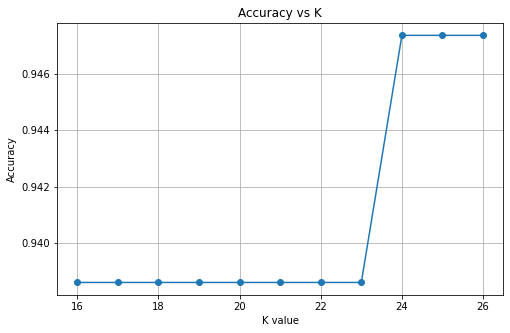

```python
plt.figure(figsize=(8,5))

plt.plot(
    list(k_values),
    accuracy,
    marker='o'
)


plt.xlabel("K value")

plt.ylabel("Accuracy")

plt.title("Accuracy vs K")

plt.grid()

plt.show()
```

This graph shows how model accuracy changes with different K values. Small K values can overfit because the model becomes sensitive to noise. Large K values can underfit because decision boundaries become overly smooth. The graph helps identify the K value that produces the highest testing accuracy.

```python
best_k = list(k_values)[
    np.argmax(accuracy)
]


print(
    "Best K:",
    best_k
)
```

```
Best K: 24
```

Among the tested values, K = 24 produced the highest accuracy on the test data. This value provides the best balance between overfitting and underfitting for the chosen split.

```python
pca=PCA(n_components=2)

X_pca=pca.fit_transform(X_scaled)


X_pca=pd.DataFrame(
    X_pca,
    columns=['PC1','PC2']
)
```

PCA reduces the original 30-dimensional dataset into only two principal components. The reduction is performed only for visualization. The original features are still used for final model training.

```python
def plot_boundary(k):

    model=KNeighborsClassifier(
        n_neighbors=k
    )

    model.fit(
        X_pca,
        y
    )


    x_min,x_max=X_pca.iloc[:,0].min()-1,X_pca.iloc[:,0].max()+1

    y_min,y_max=X_pca.iloc[:,1].min()-1,X_pca.iloc[:,1].max()+1


    xx,yy=np.meshgrid(
        np.arange(x_min,x_max,0.05),
        np.arange(y_min,y_max,0.05)
    )


    Z=model.predict(
        np.c_[xx.ravel(),yy.ravel()]
    )


    Z=Z.reshape(xx.shape)


    plt.figure(figsize=(6,5))

    plt.contourf(
        xx,
        yy,
        Z,
        alpha=0.3
    )


    plt.scatter(
        X_pca.iloc[:,0],
        X_pca.iloc[:,1],
        c=y,
        edgecolor='black'
    )


    plt.title(
        f"KNN Decision Boundary K={k}"
    )

    plt.xlabel("PC1")

    plt.ylabel("PC2")

    plt.show()
```

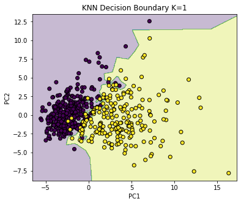

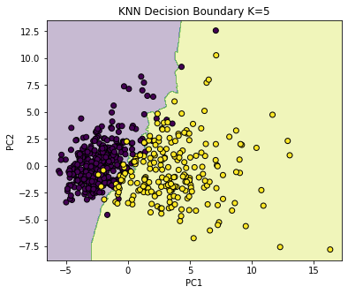

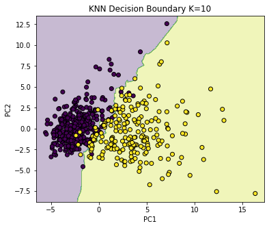

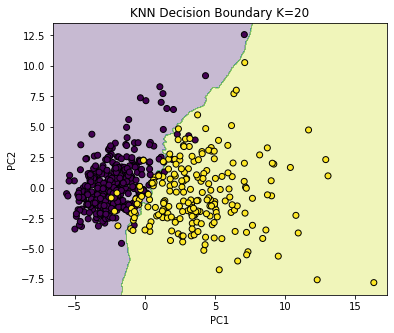

```python
for k in [1,5,10,20]:

    plot_boundary(k)
```

K = 1 Interpretation Decision boundary is highly irregular. Model memorizes the training data. Very low bias but very high variance. Highly prone to overfitting. K = 5 Interpretation Boundary becomes smoother. Better balance between bias and variance. More stable predictions than K = 1. K = 10 Interpretation Decision boundary becomes even smoother. Noise influence decreases. Model begins to generalize better. K = 20 Interpretation Decision boundary is very smooth. Model becomes less sensitive to individual observations. If K becomes too large, important local patterns may be ignored, leading to underfitting.

```python
k_values=range(1,31)

cv_results=[]


cv=KFold(
    n_splits=5,
    shuffle=True,
    random_state=42
)


for k in k_values:

    model=KNeighborsClassifier(
        n_neighbors=k
    )


    scores=cross_val_score(
        model,
        X_scaled,
        y,
        cv=cv,
        scoring='accuracy'
    )


    cv_results.append(
        scores.mean()
    )
```

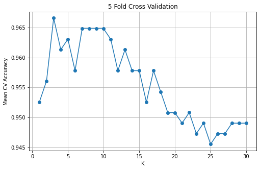

```python
plt.figure(figsize=(8,5))


plt.plot(
    list(k_values),
    cv_results,
    marker='o'
)


plt.xlabel("K")

plt.ylabel("Mean CV Accuracy")

plt.title("5 Fold Cross Validation")


plt.grid()

plt.show()
```

The graph shows average validation accuracy for different K values. Cross-validation evaluates performance across multiple train-test combinations. It provides a more reliable estimate than a single train-test split. The highest point indicates the most stable K value.

```python
best_cv_k = list(k_values)[
    np.argmax(cv_results)
]


print(
    "Best CV K:",
    best_cv_k
)
```

```
Best CV K: 3
```

Although K = 24 performed best on one train-test split, K = 3 achieved the highest average accuracy across all folds. This suggests K = 3 generalizes better to unseen data. Therefore, K = 3 is selected as the final model.

```python
final_model=KNeighborsClassifier(
    n_neighbors=best_cv_k
)


final_model.fit(
    X_train,
    y_train
)


y_pred=final_model.predict(
    X_test
)
```

```python
print("accurace: ", accuracy_score(
    y_test,
    y_pred
))
print("precision: ", precision_score(
    y_test,
    y_pred
))
print("recall: ", recall_score(
    y_test,
    y_pred
))
print("F1 score: ", f1_score(
    y_test,
    y_pred
))
```

```
accurace:  0.9385964912280702
precision:  0.972972972972973
recall:  0.8571428571428571
F1 score:  0.9113924050632912
```

Accuracy (93.86%) Nearly 94% of all tumor samples were classified correctly. Indicates strong overall model performance. Precision (97.30%) When the model predicts cancer, it is correct almost every time. Very few false positives are produced. Recall (85.71%) The model correctly detects about 86% of actual cancer cases. Around 14% of malignant cases are still missed. In medical diagnosis, improving recall is extremely important. F1 Score (91.14%) Indicates an excellent balance between precision and recall. Shows the classifier performs consistently across both metrics.

Although the model achieved 93.86% accuracy, the Recall was only 85.71%.

Insight: This means that while the overall classification performance is high, approximately 14% of actual positive cancer cases could still be missed, making Recall an essential metric for healthcare applications.

```python
print(
    classification_report(
        y_test,
        y_pred
    )
)
```

```
              precision    recall  f1-score   support

           0       0.92      0.99      0.95        72
           1       0.97      0.86      0.91        42

    accuracy                           0.94       114
   macro avg       0.95      0.92      0.93       114
weighted avg       0.94      0.94      0.94       114
```

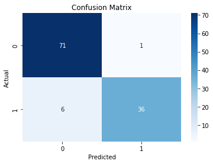

```python
cm=confusion_matrix(
    y_test,
    y_pred
)


sns.heatmap(
    cm,
    annot=True,
    fmt='d',
    cmap='Blues'
)


plt.xlabel("Predicted")

plt.ylabel("Actual")

plt.title("Confusion Matrix")

plt.show()
```

```python
y_prob=final_model.predict_proba(
    X_test
)[:,1]
auc=roc_auc_score(
    y_test,
    y_prob
)


print(
    "AUC Score:",
    auc
)
```

```
AUC Score: 0.982473544973545
```

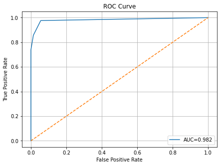

```python
fpr,tpr,thresholds=roc_curve(
    y_test,
    y_prob
)


plt.figure(figsize=(7,5))


plt.plot(
    fpr,
    tpr,
    label=f"AUC={auc:.3f}"
)


plt.plot(
    [0,1],
    [0,1],
    linestyle='--'
)


plt.xlabel("False Positive Rate")

plt.ylabel("True Positive Rate")


plt.title("ROC Curve")


plt.legend()

plt.grid()

plt.show()
```

COMPARATIVE ANALYSIS

| Regression (Lab 3) | Classification (Lab 4) |
| --- | --- |
| MAE | Accuracy |
| MSE | Precision |
| RMSE | Recall |
| R² Score | F1 Score |
| Measures numerical prediction error | Measures correctness of predicted class |

Regression predicts continuous values (e.g., house price), whereas classification predicts discrete categories (e.g., benign or malignant cancer).

Regression (Error-based) Measures how far the predicted value is from the actual value. Even a small prediction difference contributes to the error. Lower error indicates a better model.

Examples:

MAE MSE RMSE Classification (Decision-based) Measures whether the predicted class is correct or incorrect. Focuses on correct decisions instead of numerical differences. Higher metric values indicate better performance.

Examples:

Accuracy Precision Recall F1 Score ROC-AUC

Lab 3 Multiple Regression: R² = 0.8063 Lab 4 KNN: Accuracy = 93.86%

R² shows how well continuous values are explained, while Accuracy measures how many class labels are predicted correctly.

| RMSE | F1 Score |
| --- | --- |
| Regression | Classification |
| Measures average prediction error magnitude | Balances Precision and Recall |
| Lower is better | Higher is better |

Lab 3 RMSE = 10685.06 Lab 4 F1 Score = 0.9114

RMSE measures numerical prediction error, whereas F1 Score measures the balance between correctly identifying positive cases and minimizing false alarms.

| MAE | Confusion Matrix |
| --- | --- |
| Measures average absolute prediction error | Shows detailed classification outcomes |
| Gives one numerical error value | Displays TP, TN, FP, FN |
| Lower is better | Used to compute Accuracy, Precision, Recall and F1 |

MAE tells how much predictions differ from actual values, whereas the Confusion Matrix explains where the classifier makes correct and incorrect decisions.

Continuous Prediction (Regression) Predicts numerical values. Output can take any value within a range. Performance is evaluated using prediction errors.

A) Predicting house prices from area, bedrooms and other features -

Evaluation Metrics:

MAE MSE RMSE R² Score Classification Tasks Predicts predefined categories. Output belongs to a fixed class. Performance depends on correct classification.

B) Predicting whether a breast tumor is benign or malignant -

Evaluation Metrics:

Accuracy Precision Recall F1 Score ROC-AUC Confusion Matrix

Regression and classification use different evaluation metrics because they solve different problems. Regression metrics such as MAE, MSE, RMSE, and R² measure how close predicted numerical values are to the actual values and how well the model explains the data.

Classification metrics evaluate the correctness of predicted class labels. Accuracy measures overall correctness, while Precision, Recall, F1 Score, and the Confusion Matrix provide deeper insight into prediction performance.

In medical diagnosis, Accuracy alone is not enough because a model may miss patients with the disease (false negatives). Recall is more important as it measures how well the model identifies actual positive cases. ROC-AUC is also valuable because it evaluates the model's ability to distinguish between classes across different thresholds.

Overall, regression evaluation focuses on minimizing prediction errors, while classification evaluation emphasizes correct classification, especially reducing false negatives in critical applications such as cancer diagnosis.

Lab 3 focused on minimizing numerical prediction errors using MAE, MSE, RMSE, and R² Score. Lab 4 focused on maximizing correct classification using Accuracy, Precision, Recall, F1 Score, and ROC-AUC. The regression model achieved R² = 0.8063, explaining about 81% of the variation in house prices. The classification model achieved 93.86% accuracy and 0.9825 ROC-AUC, indicating excellent classification capability.

1. Why is KNN called lazy learning?

   Because KNN does not build a model during training. It stores training data and performs calculations only when prediction is required.
2. Why scaling is required?

   KNN uses distance calculations. Features with larger numerical ranges dominate smaller features.
3. √n heuristic K selection

   A common rule chooses root of n, where n is training samples. It provides a starting point for tuning.
4. Why cross validation is better?

   Because it evaluates the model on multiple data subsets and reduces dependency on one random split.
5. Effect of K on bias variance

   Small K:

   Low bias High variance Sensitive to noise

   Large K:

   High bias Low variance Smoother boundaries
6. Why recall matters in cancer detection?

   Missing a cancer case (false negative) is dangerous. High recall reduces missed malignant cases.
7. Limitation of large K

   Large K may classify everything according to the majority class and underfit the data.